# Agilent Single-Channel Microarray Processing Pipeline RMarkdown (GLDS-41)

2022-08-16

## Installing necessary packages

For processing Agilent microarray data, I needed to install a few packages that were used for the importing and analyzing the data. This included Bioconductor as well as Linear Models for Microarray (Limma). These are popular packages for processing microarray data.

```r
## For installing Bioconductor on R
# if (!require("BiocManager", quietly = TRUE))
#     install.packages("BiocManager")
# BiocManager::install(version = "3.14")

## For installing limma on R
# if (!require("BiocManager", quietly = TRUE))
#     install.packages("BiocManager")
# BiocManager::install("limma")

## For installing statmod on R
# install.packages("statmod")

##if (!require("BiocManager", quietly = TRUE))
#   install.packages("BiocManager")
#
#BiocManager::install("biomaRt")
```

## Load the packages

After installing the packages above, I had to load them in using the library function so that I could access their functions.

```r
library(limma)
library(dplyr)
library(statmod)
library(biomaRt)
```

## Importing the Raw Data

Now that the library was loaded, I was able to import the raw data. I started by importing the runsheet into R. This contained the necessary data for processing later in the pipeline.

```r
dir = "C:/Users/tangk/Desktop/Agilent_Microarray"
GLDS_41_rs <- read.csv(file.path(dir, "Runsheet(GLDS-41).csv"), check.names = FALSE, fileEncoding = 'UTF-8-BOM') ## Outputs a dataframe
Factor_Value <- GLDS_41_rs[,"Factor Value[gravity]"]

compare_csv_from_runsheet <- function(runsheet_path) {
    df = read.csv(runsheet_path, check.names = FALSE, fileEncoding = 'UTF-8-BOM') # fileEncoding removes strange characters from the column names
    # get only Factor Value columns
    factors = as.data.frame(df[,grep("Factor Value", colnames(df), ignore.case=TRUE)])
    colnames(factors) = paste("factor",1:dim(factors)[2], sep= "_")
    result = data.frame(sample_id = df[,c("Sample Name")], factors)
    return(result)
}
compare_csv <- compare_csv_from_runsheet(file.path(dir, "Runsheet(GLDS-41).csv"))
study <- as.data.frame(compare_csv[,2:dim(compare_csv)[2]])
colnames(study) <- colnames(compare_csv)[2:dim(compare_csv)[2]]
rownames(study) <- compare_csv[,1]
#DT::datatable(study, caption = "TBA")

##### Format groups and indicate the group that each sample belongs to #####
if (dim(study) >= 2){
    group<-apply(study,1,paste,collapse = " & ") # concatenate multiple factors into one condition per sample
} else{
    group<-study[,1]
}
group_names <- paste0("(",group,")",sep = "") # human readable group names
group <- make.names(group) # group naming compatible with R models
names(group) <- group_names
#DT::datatable(as.data.frame(group), caption = "TBA")
levels <- factor(group)
```

- dir = A variable that stores the location of where I kept the runsheets.
- GLDS_41_rs = A varaible that holds the contents of those runsheets.
- Factor_Value = A variable that holds specifically the factor values column from the runsheet.

Here, I imported the raw data from the text files into R using the readmaimages() function from the Limma package.

```r
datadir = "C:/Users/tangk/Desktop/Agilent_Microarray/input_data"
files = dir(path = file.path(datadir, "GLDS-41/GLDS-41_Raw_Data"), pattern="*\\.txt$")

## Input: ".txt" files, Output: EListRaw (Raw intensities)
raw_data <- limma::read.maimages(files, source="agilent", path = file.path(datadir, "GLDS-41/GLDS-41_Raw_Data"), sep="\t", green.only = TRUE, other.columns="gIsWellAboveBG")
```

```
## Read C:/Users/tangk/Desktop/Agilent_Microarray/input_data/GLDS-41/GLDS-41_Raw_Data/GSM675861.txt
## Read C:/Users/tangk/Desktop/Agilent_Microarray/input_data/GLDS-41/GLDS-41_Raw_Data/GSM675862.txt
## Read C:/Users/tangk/Desktop/Agilent_Microarray/input_data/GLDS-41/GLDS-41_Raw_Data/GSM675863.txt
## Read C:/Users/tangk/Desktop/Agilent_Microarray/input_data/GLDS-41/GLDS-41_Raw_Data/GSM675864.txt
## Read C:/Users/tangk/Desktop/Agilent_Microarray/input_data/GLDS-41/GLDS-41_Raw_Data/GSM675865.txt
## Read C:/Users/tangk/Desktop/Agilent_Microarray/input_data/GLDS-41/GLDS-41_Raw_Data/GSM675866.txt
## Read C:/Users/tangk/Desktop/Agilent_Microarray/input_data/GLDS-41/GLDS-41_Raw_Data/GSM675867.txt
## Read C:/Users/tangk/Desktop/Agilent_Microarray/input_data/GLDS-41/GLDS-41_Raw_Data/GSM675868.txt
## Read C:/Users/tangk/Desktop/Agilent_Microarray/input_data/GLDS-41/GLDS-41_Raw_Data/GSM675869.txt
## Read C:/Users/tangk/Desktop/Agilent_Microarray/input_data/GLDS-41/GLDS-41_Raw_Data/GSM675870.txt
## Read C:/Users/tangk/Desktop/Agilent_Microarray/input_data/GLDS-41/GLDS-41_Raw_Data/GSM675871.txt
## Read C:/Users/tangk/Desktop/Agilent_Microarray/input_data/GLDS-41/GLDS-41_Raw_Data/GSM675872.txt
## Read C:/Users/tangk/Desktop/Agilent_Microarray/input_data/GLDS-41/GLDS-41_Raw_Data/GSM675873.txt
## Read C:/Users/tangk/Desktop/Agilent_Microarray/input_data/GLDS-41/GLDS-41_Raw_Data/GSM675874.txt
## Read C:/Users/tangk/Desktop/Agilent_Microarray/input_data/GLDS-41/GLDS-41_Raw_Data/GSM675875.txt
## Read C:/Users/tangk/Desktop/Agilent_Microarray/input_data/GLDS-41/GLDS-41_Raw_Data/GSM675876.txt
## Read C:/Users/tangk/Desktop/Agilent_Microarray/input_data/GLDS-41/GLDS-41_Raw_Data/GSM675877.txt
## Read C:/Users/tangk/Desktop/Agilent_Microarray/input_data/GLDS-41/GLDS-41_Raw_Data/GSM675878.txt
```

- datadir = A variable that stores the path to the directory that holds the three datasets that I have chosen.
- files = A variable that will detect all of the text files within the GLDS-41_Raw_Data directory. This is where all of the raw Agilent microarray data is stored for the GLDS-41 dataset.
- source = “agilent” because the data that I want to import will be agilent microarray data. There are other options for this flag for other types of microarrays
- path = The path to the directory that holds the dataset’s raw data.
- sep = How the data is separated in those raw data files (in our case it’s tab separated).
- green.only = TRUE, This command is for telling the function that it should only read the green (Cys3) channel rather than red and green since we’re only looking at single channel microarrays.

## QC of the Raw Data

In this step, I used some diagnostic functions from the limma package to get a sense of the raw data and to see if there were any abnormalities present.

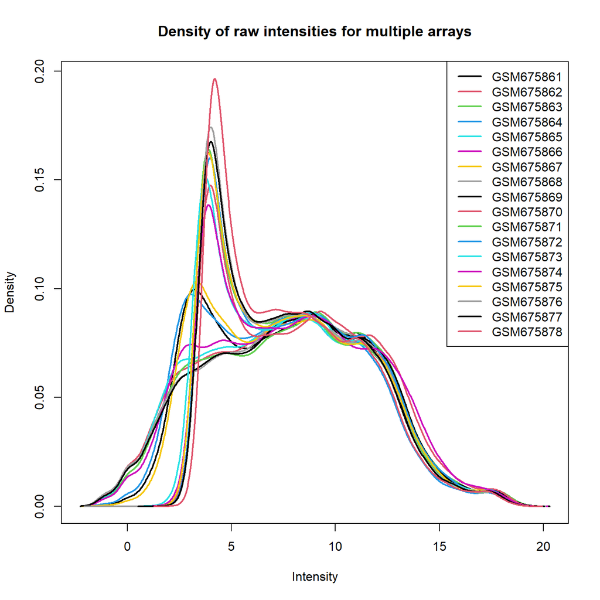

```r
# This code block uses the plotDensities() function from limma to generate a graph with the raw intensities vs. density
suppressWarnings(plotDensities(raw_data, log = TRUE, legend = "topright" , main = "Density of raw intensities for multiple arrays"))
```

```r
# Some not a number (NaNs) errors appeared (possibly due to log transformations), but overall doesn't obscure the plot so I suppressed the warnings.
```

## TODO: Track the NaNs (Not a Number errors)

- raw_data = EListRaw object containing the raw intensities and information about the arrays
- log = Specifying the densities should be plotted on the log2 scale
- legend = Specifying where the legend should be placed on the graph
- main = title of the graph

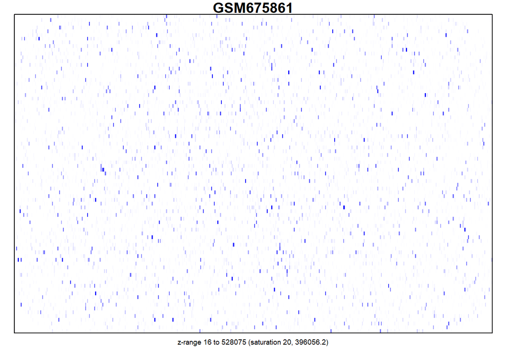

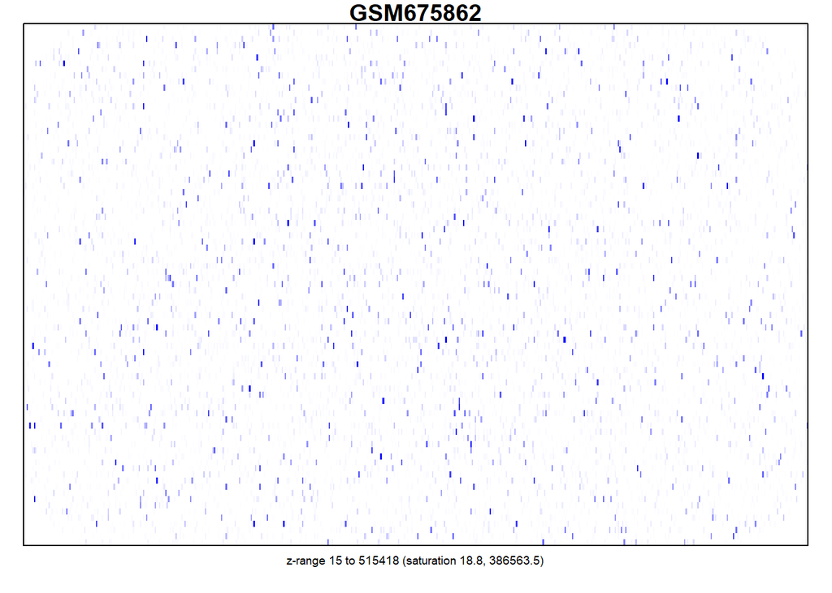

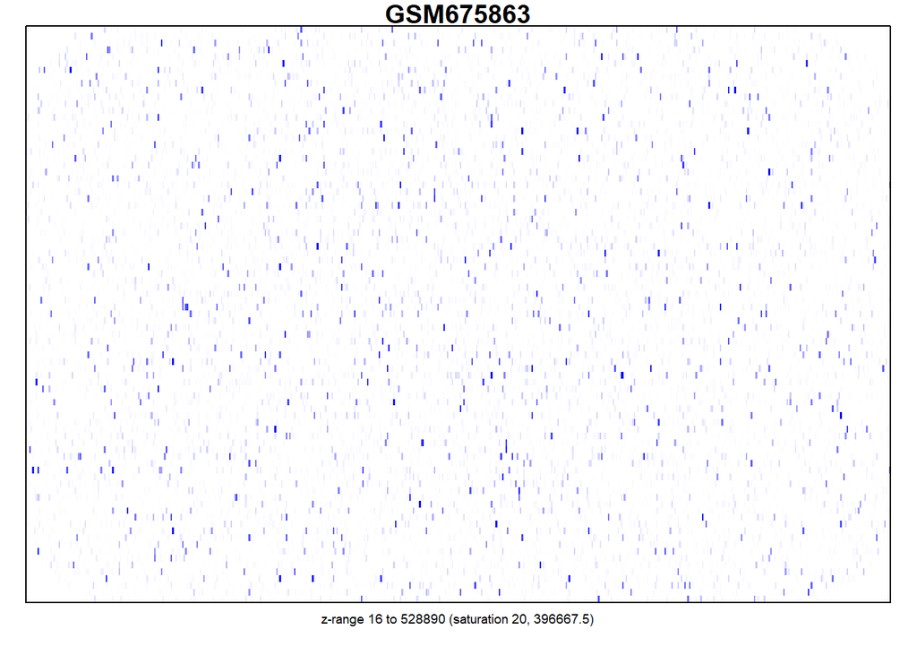

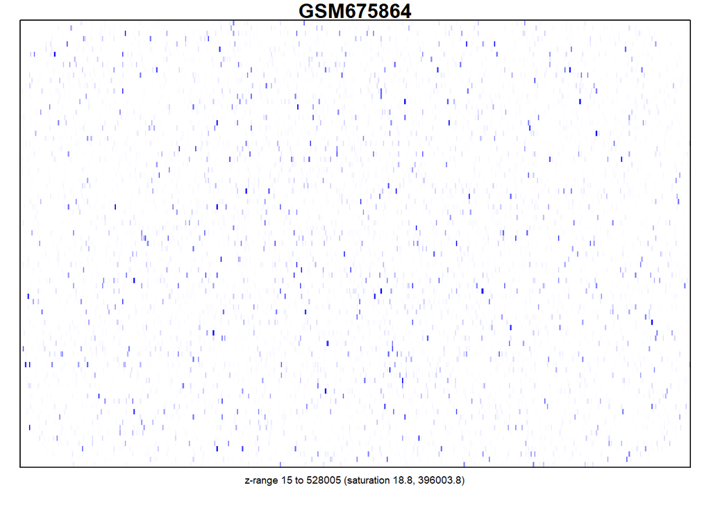

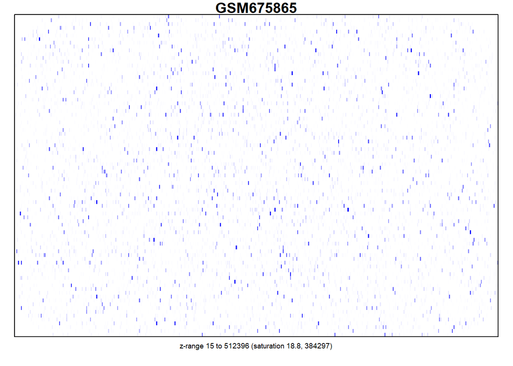

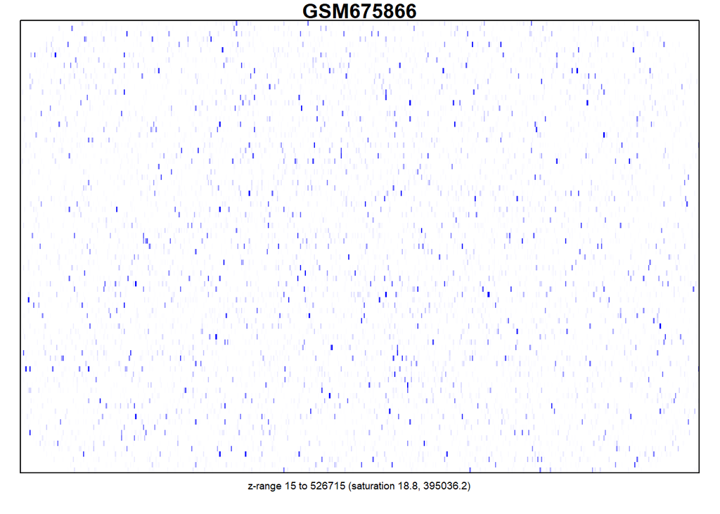

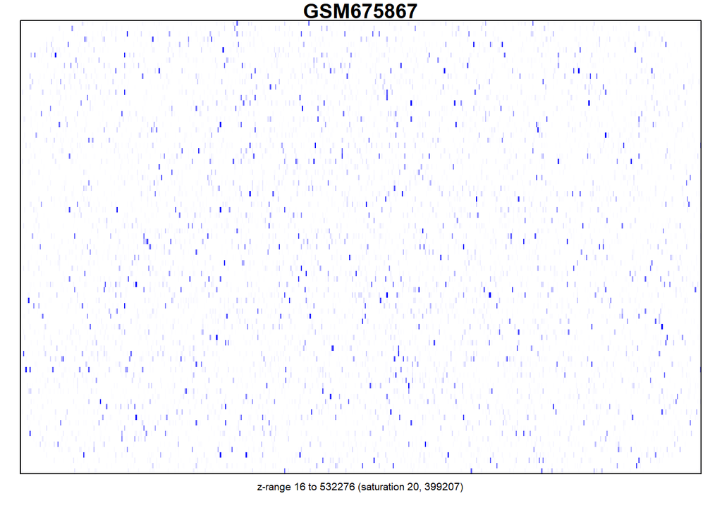

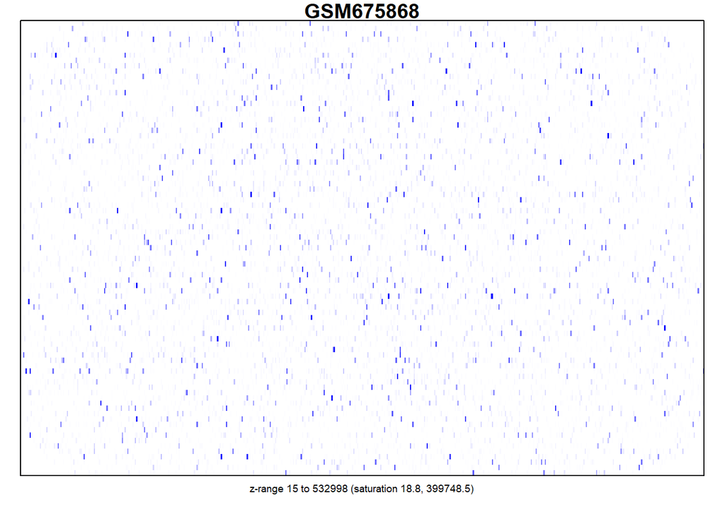

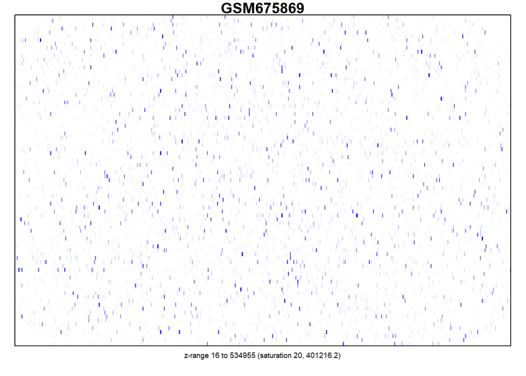

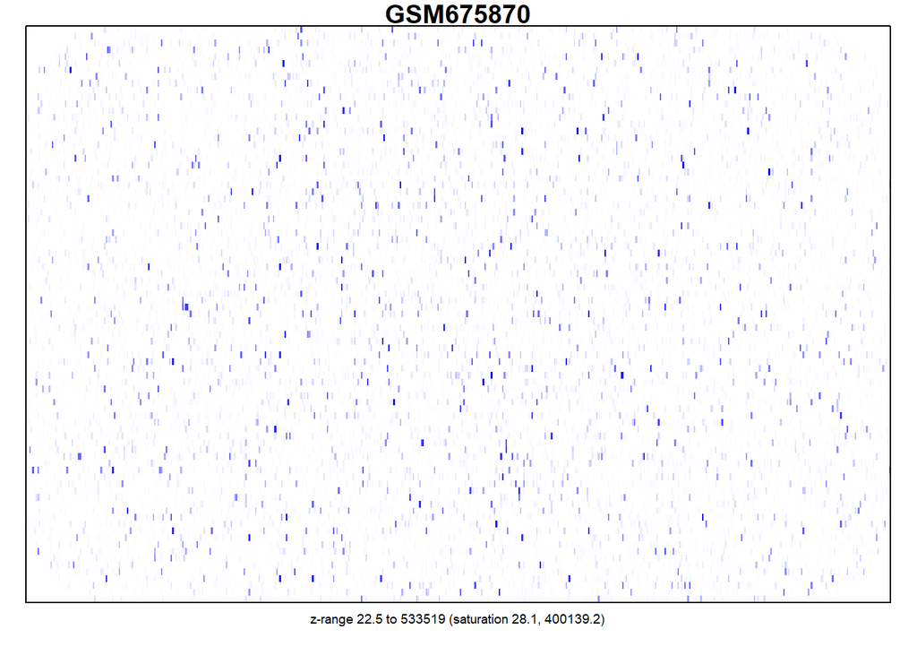

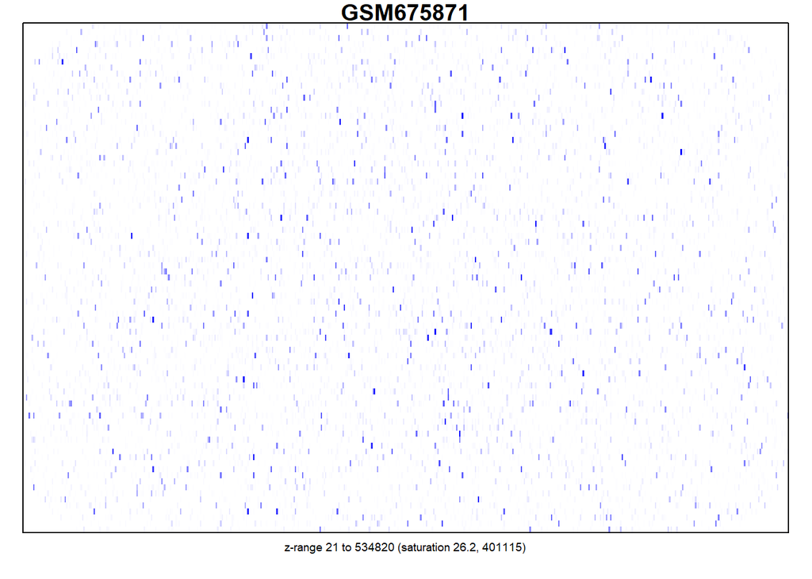

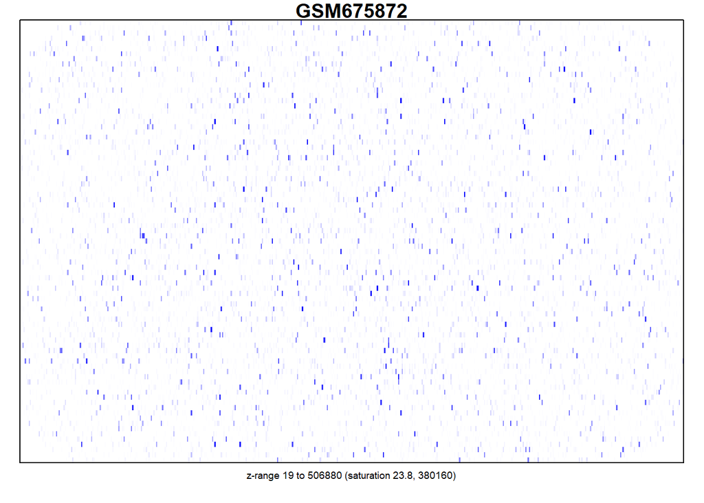

[6 more figures not shown]

```r
# This code block uses the imageplot() function to generate a pseudoimage for each sample to allow the user to look for any spatial abnormalities in the expressions on the chip.
num_rows <- nrow(raw_data)

find_factors <- function(num) {
    factors_list <- list()
    for (n in 1:num) {
        if((num %% n) == 0) {
            factors_list <- c(factors_list, n)
        }
    }
    return(factors_list)
}
factors <- find_factors(num_rows)

for (sample_name in colnames(raw_data$E)) {
    if (length(raw_data$printer) != 0)  {
        imageplot(raw_data$E[,sample_name], layout=raw_data$printer, zlim = c((1.25*min(raw_data$E[,sample_name])),(0.75*max(raw_data$E[,sample_name]))), legend = TRUE, main = sample_name)
        }
    else {
        if (length(factors) %% 2 == 0) {
            rows <- factors[[length(factors)/2]]
            columns <- factors[[length(factors)/2+1]]
            }
        else {
            rows <- factors[[ceiling(length(factors)/2)]]
            columns <- factors[[ceiling(length(factors)/2)]]
            }
        imageplot(raw_data$E[,sample_name], layout=list(ngrid.r = 1, ngrid.c = 1, nspot.r = 532, nspot.c = 85), zlim = c((1.25*min(raw_data$E[,sample_name])),(0.75*max(raw_data$E[,sample_name]))), legend = TRUE, main = sample_name)
        }
}
```

- raw_data$E[, sample_name] = specifying that we want to use the raw expression values (rows) from each sample (column) as the data for a plot
- layout = using the values from the printer variable from raw_data to specify the dimensions of the pseudoimage generated
- zlim = altering the range of intensities that will be plotted (min = 1.25 min raw expression value, max = 0.75 max raw expression value)
- legend = displays the range of the z values (raw expresison values)

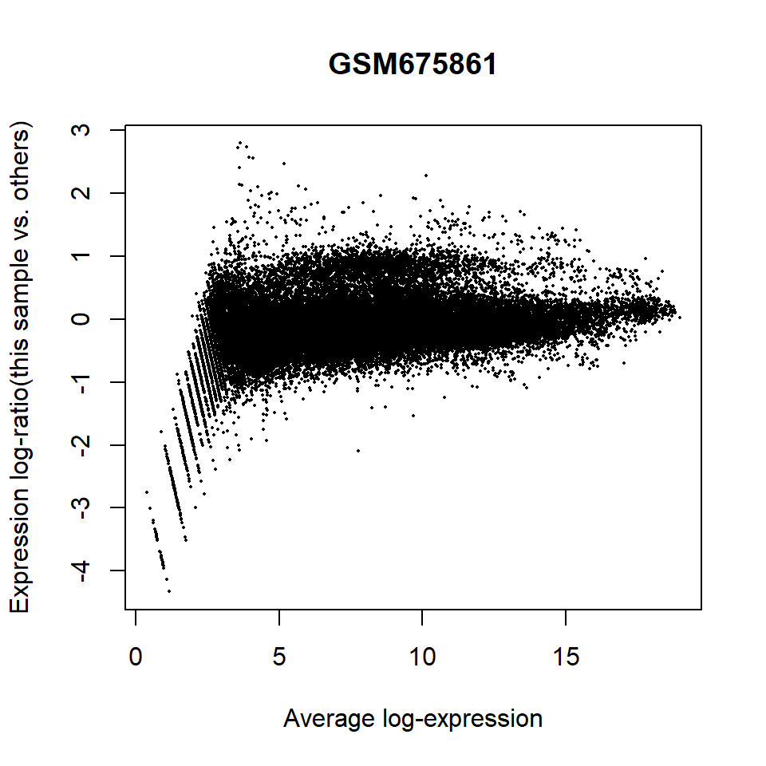

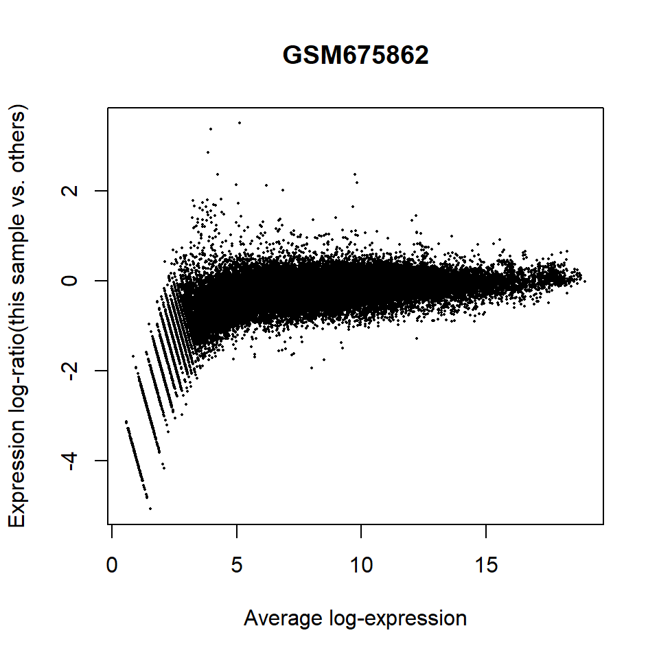

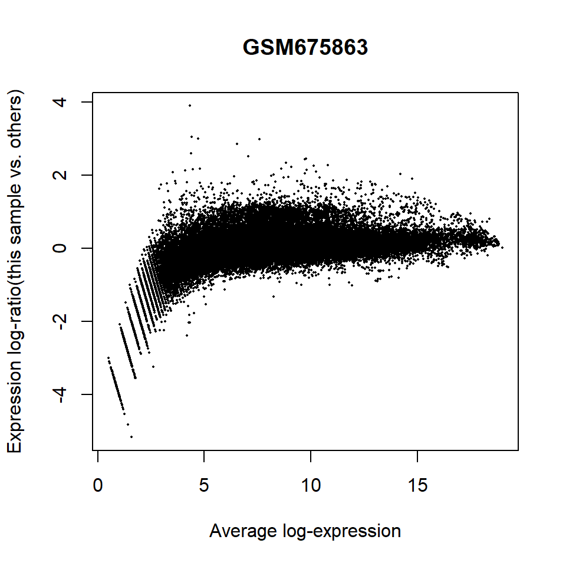

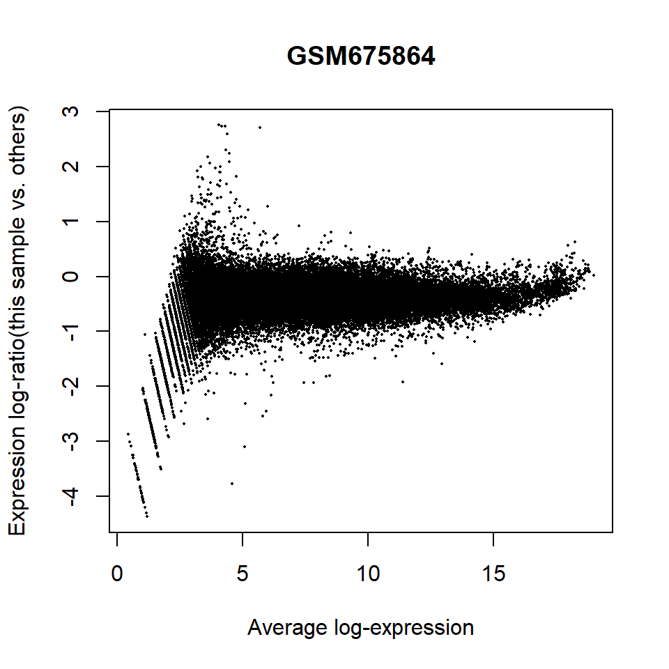

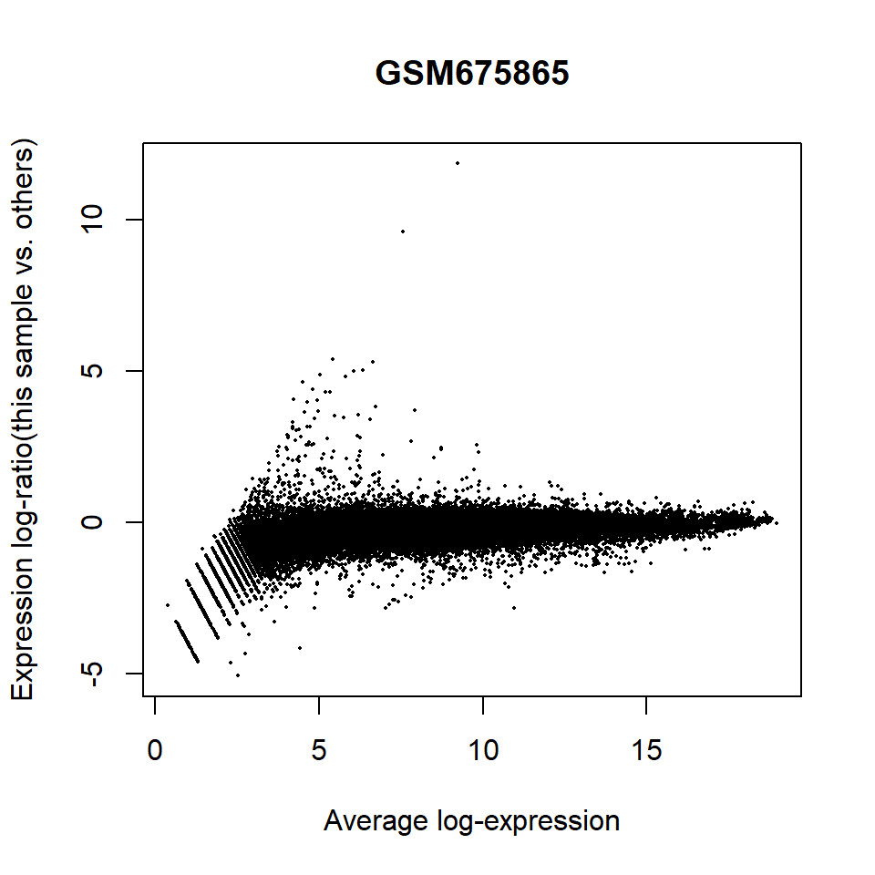

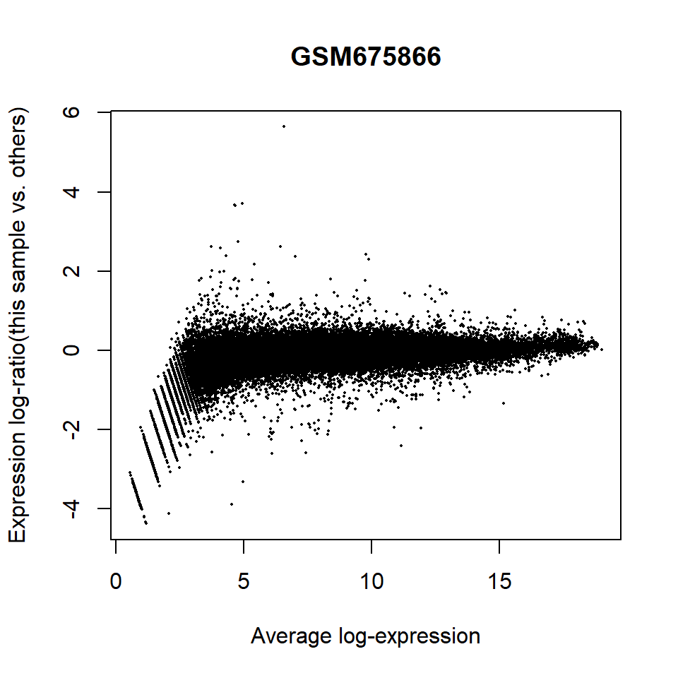

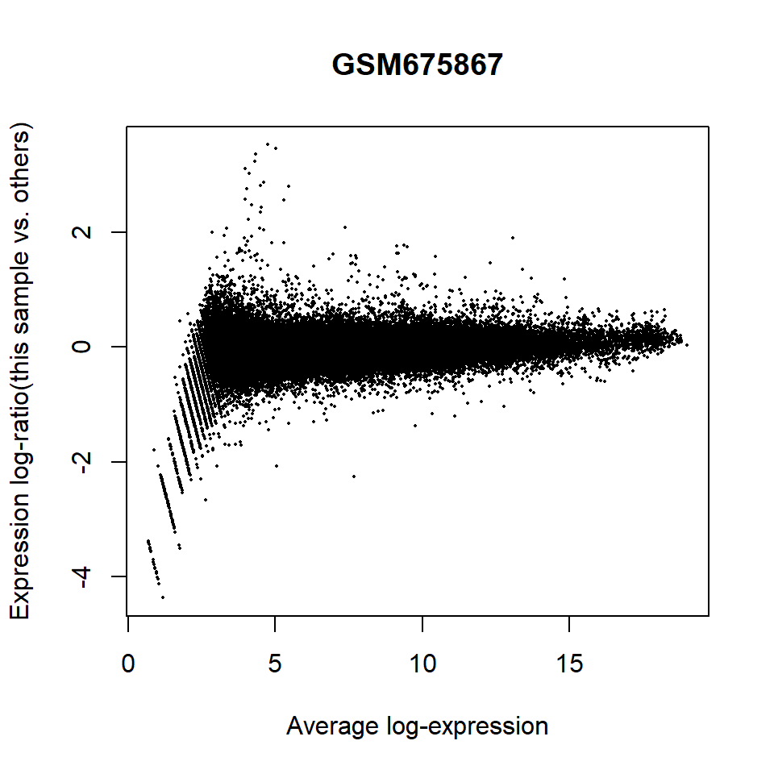

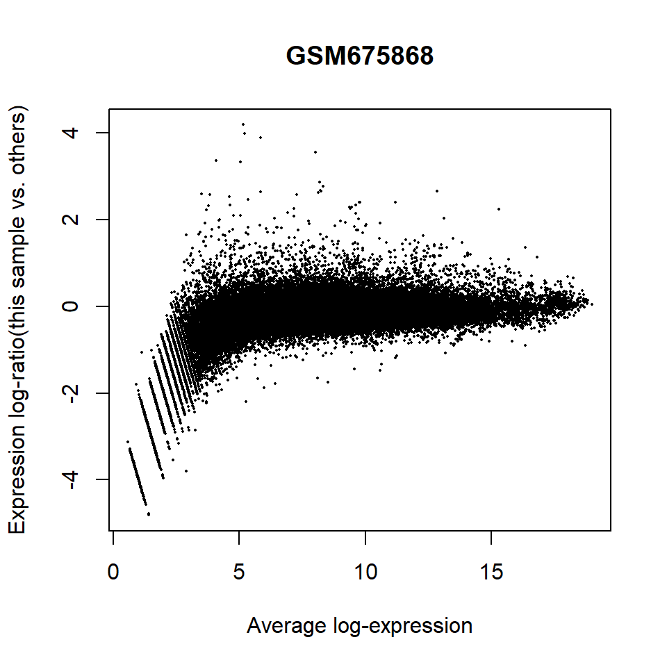

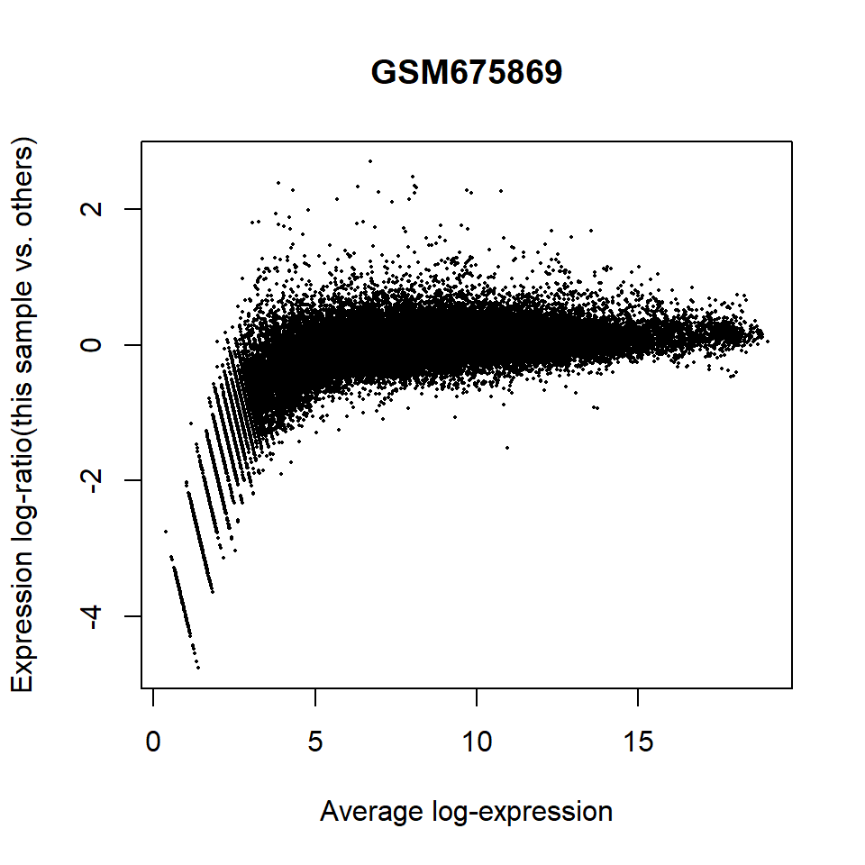

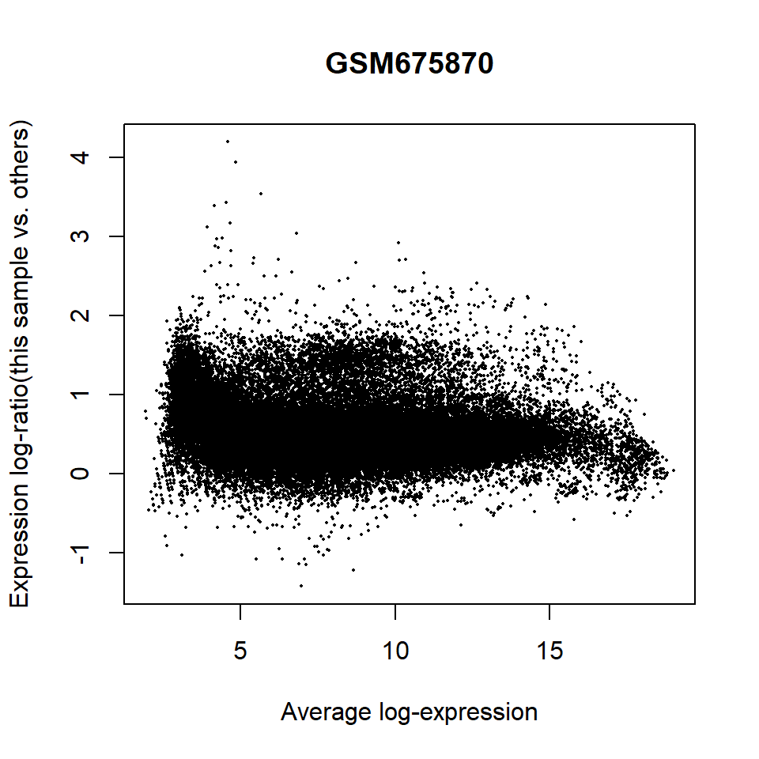

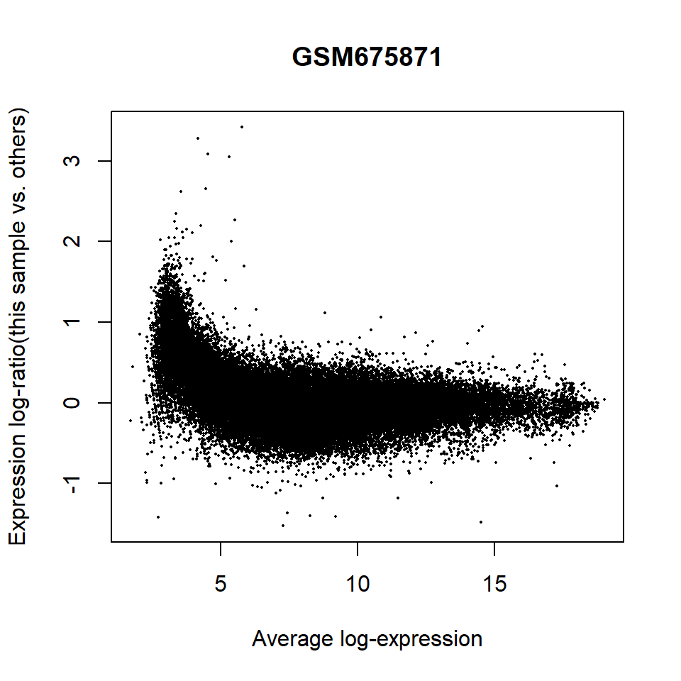

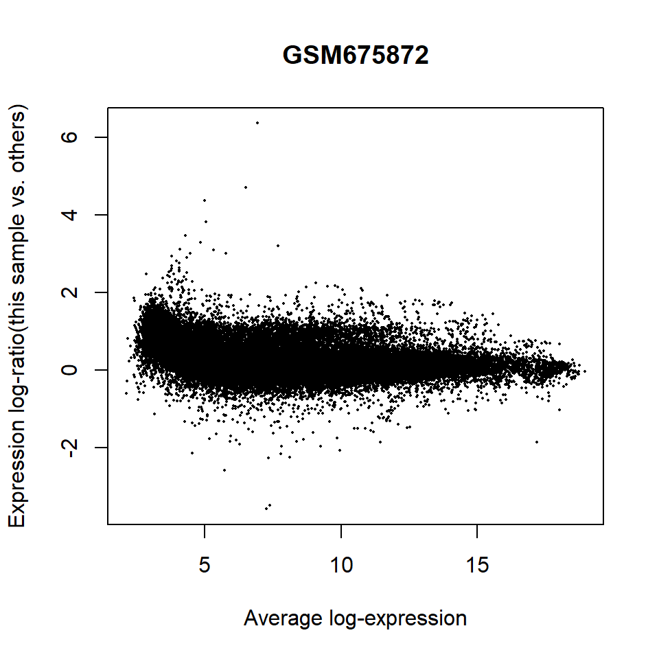

[6 more figures not shown]

```r
# This code block uses the plotMA() function from limma to generate a MA plot for each of the samples.
count = 0
for (sample_name in colnames(raw_data$E)) {
    count = count + 1
    suppressWarnings(limma::plotMA(raw_data,array=count,xlab="Average log-expression",ylab="Expression log-ratio(this sample vs. others)", main = sample_name))
}
```

```r
# There were NaN errors popping up due to the log transformations going on, but they didn't obscure the plots generated, so I went ahead and suppressed the warnings.
```

- raw_data = EListRaw object containing the raw expression values and information about the arrays
- array = choosing which array (sample) to use the data from
- xlab = label for the x axis
- ylab = label for the y axis
- main = title for the plot